# Modules 2

- `matplotlib`: Data visualization.
- `pandas`: Data analysis.

## Deep Dive: `matplotlib`

- Visualization library for Python.
- Produces 2D and 3D plots and graphs.
- Highly customizable.
- The most common submodule is `pyplot`, normally imported as `plt`.

```python
import matplotlib.pyplot as plt
```

```python
x = [10, 20, 30, 40, 50]
y = [1, 2, 3, 4, 5]
```

### Line

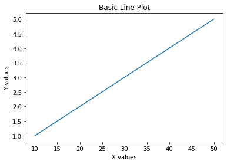

```python
# Plotting a line with X and Y points
plt.plot(x, y)

# Add a label to the x-axis
plt.xlabel('X values')
# Add a label to the y-axis
plt.ylabel('Y values')
# Add a title to the plot
plt.title('Basic Line Plot')
# Display the plot
plt.show()
```

### Customization with color and makers

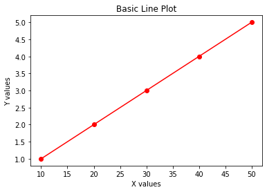

```python
# Plotting a line with X and Y points
plt.plot(x, y, color='red', marker='o')

# Add a label to the x-axis
plt.xlabel('X values')
# Add a label to the y-axis
plt.ylabel('Y values')
# Add a title to the plot
plt.title('Basic Line Plot')
# Display the plot
plt.show()
```

### Multiple line plots

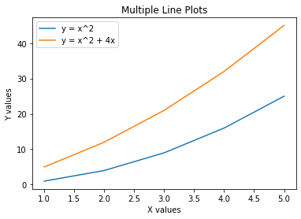

```python
x = [1, 2, 3, 4, 5]
y1 = [1, 4, 9, 16, 25]
y2 = [5, 12, 21, 32, 45]

plt.plot(x, y1, label='y = x^2')
plt.plot(x, y2, label='y = x^2 + 4x')
plt.xlabel('X values')
plt.ylabel('Y values')
plt.title('Multiple Line Plots')

# Add a legend
plt.legend()
plt.show()
```

### Bar chart

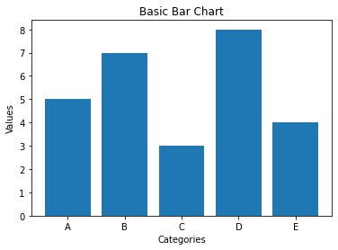

```python
categories = ['A', 'B', 'C', 'D', 'E']
values = [5, 7, 3, 8, 4]

plt.bar(categories, values)
plt.xlabel('Categories')
plt.ylabel('Values')
plt.title('Basic Bar Chart')
plt.show()
```

### Pie chart

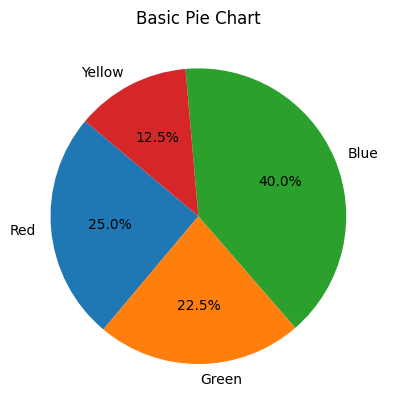

```python
labels = ['Red', 'Green', 'Blue', 'Yellow']
sizes = [50, 45, 80, 25]

plt.pie(sizes, labels=labels, autopct='%1.1f%%', startangle=140)
plt.title('Basic Pie Chart')
plt.show()
```

### Scatter plot

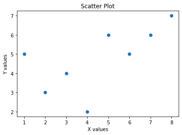

```python
x = [1, 2, 3, 4, 5, 6, 7, 8]
y = [5, 3, 4, 2, 6, 5, 6, 7]

plt.scatter(x, y)
plt.xlabel('X values')
plt.ylabel('Y values')
plt.title('Scatter Plot')
plt.show()
```

### Histogram

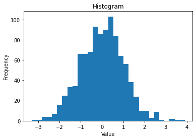

```python
import numpy as np

# Generate random data from a normal distribution
data = np.random.randn(1000)

plt.hist(data, bins=30)
plt.title("Histogram")
plt.xlabel("Value")
plt.ylabel("Frequency")
plt.show()
```

## Deep Dive: `pandas`

- Data analysis library in Python.
- Offers DataFrames (tabular data structures).
- Powerful for data wrangling and exploration.
- Normally imported as `pd`.

```python
import pandas as pd
```

```python
data = {
    "Name": ["Alice", "Bob", "Charlie"],
    "Age": [25, 30, 35],
    "City": ["NY", "LA", "SF"],
    "Salary": [100, 200, 300]
}

# Create a DataFrame from data in a dictionary
df = pd.DataFrame(data)
print(df)
```

```
      Name  Age City  Salary
0    Alice   25   NY     100
1      Bob   30   LA     200
2  Charlie   35   SF     300
```

```python
type(df)
```

```
pandas.core.frame.DataFrame
```

```python
# (rows, columns) size of the dataframe
df.shape
```

```
(3, 4)
```

```python
# Total size of the dataframe
df.size
```

```
12
```

```python
# Column names
df.columns
```

```
Index(['Name', 'Age', 'City', 'Salary'], dtype='object')
```

### Access columns

```python
# Access the column 'Name'
df['Name']
```

```
0      Alice
1        Bob
2    Charlie
Name: Name, dtype: object
```

```python
# As type `list`
df['Name'].to_list()
```

```
['Alice', 'Bob', 'Charlie']
```

```python
# Access multiple columns
df[['Name', 'Salary']]
```

|  | Name | Salary |
| --- | --- | --- |
| 0 | Alice | 100 |
| 1 | Bob | 200 |
| 2 | Charlie | 300 |

### Indices

- Indices are **unique** identifiers for each row.
- By default, the range is [0, dataframe's length - 1].
- As long as their values are unique, we can use any values we want as an index.

```python
# Setting 'Name' as index
df.set_index('Name', inplace=True)
print(df)
```

```
         Age City  Salary
Name
Alice     25   NY     100
Bob       30   LA     200
Charlie   35   SF     300
```

```python
# Resetting to default index
df.reset_index(inplace=True)
print(df)
```

```
      Name  Age City  Salary
0    Alice   25   NY     100
1      Bob   30   LA     200
2  Charlie   35   SF     300
```

### Access rows

#### `loc`

Label-based indexing.

```python
# Setting 'Name' as index
df.set_index('Name', inplace=True)
```

```python
# Access attributes of index 'Alice'
df.loc['Alice']
```

```
Age        25
City       NY
Salary    100
Name: Alice, dtype: object
```

```python
# Access specific attribute of 'Alice' index
df.loc['Alice', 'City']
```

```
'NY'
```

#### `iloc`

Position-based indexing.

```python
# Access attributes of second (0-based) row, which is Bob's
df.iloc[1]
```

```
Age        30
City       LA
Salary    200
Name: Bob, dtype: object
```

```python
# Access specific attribute (by 0-based index as well)
df.iloc[1, 0]
```

```
30
```

```python
# Access rows with an index range
df.iloc[0:2]
```

| Name | Age | City | Salary |
| --- | --- | --- | --- |
| Alice | 25 | NY | 100 |
| Bob | 30 | LA | 200 |

```python
# Access rows and columns with index ranges
df.iloc[0:2, 1:3]
```

| Name | City | Salary |
| --- | --- | --- |
| Alice | NY | 100 |
| Bob | LA | 200 |

### Series

- One-dimensional labeled array.
- Can contain any data type.

```python
# Accessing a column gives a Series object,
# which is a one-dimensional array of data labels (Names)
df['City']
```

```
Name
Alice      NY
Bob        LA
Charlie    SF
Name: City, dtype: object
```

```python
type(df['City'])
```

```
pandas.core.series.Series
```

```python
# Accessing first element of the column
df['City'][0]
```

```
'NY'
```

### Filtering

- We can filter data with boolean `Series`
- `True` values are kept, `False` values are dropped

```python
df
```

| Name | Age | City | Salary |
| --- | --- | --- | --- |
| Alice | 25 | NY | 100 |
| Bob | 30 | LA | 200 |
| Charlie | 35 | SF | 300 |

```python
# Create a binary filter for the names
binary_filter = pd.Series({"Alice": True, "Bob": False, "Charlie": True})
binary_filter
```

```
Alice       True
Bob        False
Charlie     True
dtype: bool
```

```python
# Filter the dataframe
df[binary_filter]
```

| Name | Age | City | Salary |
| --- | --- | --- | --- |
| Alice | 25 | NY | 100 |
| Charlie | 35 | SF | 300 |

Comparing columns return a boolean series, so we can use this for filtering as well!

```python
adults = df['Age'] > 28
adults
```

```
Name
Alice      False
Bob         True
Charlie     True
Name: Age, dtype: bool
```

```python
# Filtering data
df[adults]
```

| Name | Age | City | Salary |
| --- | --- | --- | --- |
| Bob | 30 | LA | 200 |
| Charlie | 35 | SF | 300 |

### Multiple filters

- Use `&` for AND operations.
- Use `|` for OR operations.
- Parentheses are crucial for multiple conditions.

```python
df
```

| Name | Age | City | Salary |
| --- | --- | --- | --- |
| Alice | 25 | NY | 100 |
| Bob | 30 | LA | 200 |
| Charlie | 35 | SF | 300 |

```python
# Get elements with age > 20 and city = NY
df[(df['Age'] > 20) & (df['City'] == 'NY')]
```

| Name | Age | City | Salary |
| --- | --- | --- | --- |
| Alice | 25 | NY | 100 |

```python
# Get elements with age > 28 or salary <= 300
df[(df['Age'] > 28) | (df['Salary'] <= 300)]
```

| Name | Age | City | Salary |
| --- | --- | --- | --- |
| Alice | 25 | NY | 100 |
| Bob | 30 | LA | 200 |
| Charlie | 35 | SF | 300 |

### String functions

```python
# String column 'City' to lower case
df['City'].str.lower()
```

```
Name
Alice      ny
Bob        la
Charlie    sf
Name: City, dtype: object
```

If not specifically stated, the dataframe does not change:

```python
# Cities are still in upper case
df
```

| Name | Age | City | Salary |
| --- | --- | --- | --- |
| Alice | 25 | NY | 100 |
| Bob | 30 | LA | 200 |
| Charlie | 35 | SF | 300 |

```python
# Change Bob's City
df.loc['Bob', 'City'] = 'NY'
```

```python
df
```

| Name | Age | City | Salary |
| --- | --- | --- | --- |
| Alice | 25 | NY | 100 |
| Bob | 30 | NY | 200 |
| Charlie | 35 | SF | 300 |

A lot of dataframe's functions have an `inplace` parameter, used when we want to keep the changes in the dataframe.

```python
# Replace values in a column
df['City'].replace({'NY': 'New York', 'SF': 'San Francisco'}, inplace=True)
```

```python
df
```

| Name | Age | City | Salary |
| --- | --- | --- | --- |
| Alice | 25 | New York | 100 |
| Bob | 30 | New York | 200 |
| Charlie | 35 | San Francisco | 300 |

We can chain as many functions as we want:

```python
# Set upper case and replace spaces with underscores
df['City'].str.upper().str.replace(' ', '_')
```

```
Name
Alice           NEW_YORK
Bob             NEW_YORK
Charlie    SAN_FRANCISCO
Name: City, dtype: object
```

### Other functions

```python
# Sum of salaries
df['Salary'].sum()
```

```
600
```

```python
# Mean age
df['Age'].mean()
```

```
30.0
```

```python
# Std of age
df['Age'].std()
```

```
5.0
```

```python
# Unique values
df['City'].unique()
```

```
array(['New York', 'San Francisco'], dtype=object)
```

```python
# Number of elements of each unique value
df['City'].value_counts()
```

```
New York         2
San Francisco    1
Name: City, dtype: int64
```

### Applying functions

- Perform operations on each element.
- More flexibility than built-in functions.

```python
# Applying a function and creating a new column
df['Age_squared'] = df['Age'].apply(lambda x: x**2)
```

```python
df
```

| Name | Age | City | Salary | Age_squared |
| --- | --- | --- | --- | --- |
| Alice | 25 | New York | 100 | 625 |
| Bob | 30 | New York | 200 | 900 |
| Charlie | 35 | San Francisco | 300 | 1225 |

### Grouping data

- Group by one or more columns.
- Aggregate using sum, mean, etc.

```python
# Grouping by 'City' and getting mean age
grouped = df.groupby('City')['Age'].mean()
print(grouped)
```

```
City
New York         27.5
San Francisco    35.0
Name: Age, dtype: float64
```

### Merging and Joining

- Combine DataFrames based on common columns.
- Types: inner, outer, left, right.

```python
df1 = pd.DataFrame({'key': ['A', 'B', 'C'], 'value1': [1, 2, 3]})
df2 = pd.DataFrame({'key': ['A', 'B', 'D'], 'value2': [4, 5, 6]})
```

```python
df1
```

|  | key | value1 |
| --- | --- | --- |
| 0 | A | 1 |
| 1 | B | 2 |
| 2 | C | 3 |

```python
df2
```

|  | key | value2 |
| --- | --- | --- |
| 0 | A | 4 |
| 1 | B | 5 |
| 2 | D | 6 |

```python
# Inner merge (intersection)
pd.merge(df1, df2, on='key', how='inner')
```

|  | key | value1 | value2 |
| --- | --- | --- | --- |
| 0 | A | 1 | 4 |
| 1 | B | 2 | 5 |

```python
# Outer merge (union of keys)
merged = pd.merge(df1, df2, on='key', how='outer')
print(merged)
```

```
  key  value1  value2
0   A     1.0     4.0
1   B     2.0     5.0
2   C     3.0     NaN
3   D     NaN     6.0
```

### Missing data

Also known as `NA` or `NaN`.

```python
merged
```

|  | key | value1 | value2 |
| --- | --- | --- | --- |
| 0 | A | 1.0 | 4.0 |
| 1 | B | 2.0 | 5.0 |
| 2 | C | 3.0 | NaN |
| 3 | D | NaN | 6.0 |

```python
# Remove rows with NaNs
df_with_no_nans = merged.dropna()
df_with_no_nans
```

|  | key | value1 | value2 |
| --- | --- | --- | --- |
| 0 | A | 1.0 | 4.0 |
| 1 | B | 2.0 | 5.0 |

```python
# Fill missing values with a 0
merged.fillna(0)
```

|  | key | value1 | value2 |
| --- | --- | --- | --- |
| 0 | A | 1.0 | 4.0 |
| 1 | B | 2.0 | 5.0 |
| 2 | C | 3.0 | 0.0 |
| 3 | D | 0.0 | 6.0 |

```python
# More complex filling: with mean values
merged[['value1', 'value2']].fillna(merged[['value1', 'value2']].mean())
```

|  | value1 | value2 |
| --- | --- | --- |
| 0 | 1.0 | 4.0 |
| 1 | 2.0 | 5.0 |
| 2 | 3.0 | 5.0 |
| 3 | 2.0 | 6.0 |

### Datetime

```python
store = {
    "Date": ["2019-01-01 20:00", "2019-01-02 20:00", "2019-02-03 20:00", "2019-02-04 20:00"],
    "Sales": [1000, 1200, 1300, 1100],
}
```

```python
# Convert dictionary to dataframe
df = pd.DataFrame(store)
df
```

|  | Date | Sales |
| --- | --- | --- |
| 0 | 2019-01-01 20:00 | 1000 |
| 1 | 2019-01-02 20:00 | 1200 |
| 2 | 2019-02-03 20:00 | 1300 |
| 3 | 2019-02-04 20:00 | 1100 |

```python
print(df['Date'].dtype)

# Convert the Date string column to datetime
df['Date'] = pd.to_datetime(df['Date'])

print(df['Date'].dtype)
```

```
object
datetime64[ns]
```

Apply datetime functions, for example:

```python
# Days of the week names
df['Date'].dt.day_name()
```

```
0      Tuesday
1    Wednesday
2       Sunday
3       Monday
Name: Date, dtype: object
```

```python
# Obtain years
df['Date'].dt.year
```

```
0    2019
1    2019
2    2019
3    2019
Name: Date, dtype: int64
```

```python
# Or months
df['Date'].dt.month
```

```
0    1
1    1
2    2
3    2
Name: Date, dtype: int64
```

```python
# Or the hour
df['Date'].dt.hour
```

```
0    20
1    20
2    20
3    20
Name: Date, dtype: int64
```

```python
# Add some time to each instance
df['Date'] + pd.Timedelta(hours=1)
```

```
0   2019-01-01 21:00:00
1   2019-01-02 21:00:00
2   2019-02-03 21:00:00
3   2019-02-04 21:00:00
Name: Date, dtype: datetime64[ns]
```

### Datetime ranges

```python
# Creating a date range with daily frequency
dates = pd.date_range(start="2023-01-01", end="2023-01-15", freq="1D")
dates
```

```
DatetimeIndex(['2023-01-01', '2023-01-02', '2023-01-03', '2023-01-04',
               '2023-01-05', '2023-01-06', '2023-01-07', '2023-01-08',
               '2023-01-09', '2023-01-10', '2023-01-11', '2023-01-12',
               '2023-01-13', '2023-01-14', '2023-01-15'],
              dtype='datetime64[ns]', freq='D')
```

```python
# Or even hour frequency
dates = pd.date_range(start="2023-01-01", end="2023-01-15", freq="1H")
dates
```

```
DatetimeIndex(['2023-01-01 00:00:00', '2023-01-01 01:00:00',
               '2023-01-01 02:00:00', '2023-01-01 03:00:00',
               '2023-01-01 04:00:00', '2023-01-01 05:00:00',
               '2023-01-01 06:00:00', '2023-01-01 07:00:00',
               '2023-01-01 08:00:00', '2023-01-01 09:00:00',
               ...
               '2023-01-14 15:00:00', '2023-01-14 16:00:00',
               '2023-01-14 17:00:00', '2023-01-14 18:00:00',
               '2023-01-14 19:00:00', '2023-01-14 20:00:00',
               '2023-01-14 21:00:00', '2023-01-14 22:00:00',
               '2023-01-14 23:00:00', '2023-01-15 00:00:00'],
              dtype='datetime64[ns]', length=337, freq='H')
```

### Read files

Read files from different formats, e.g. CSV or Excel.

```python
# Read from CSV file (this does not work, as the file does not exist)
df = pd.read_csv('data.csv')
```

```python
# Read from Excel file (this does not work, as the file does not exist)
df = pd.read_excel('data.xlsx')
```

### Plots

We can display plots in `pandas`, which uses `matplotlib` underneath.

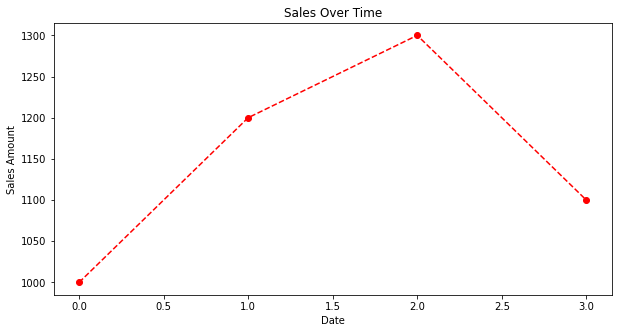

```python
# Simple time-series plot
df['Sales'].plot(figsize=(10,5), marker='o', linestyle='--', color='red')
plt.title("Sales Over Time")
plt.xlabel("Date")
plt.ylabel("Sales Amount")
plt.show()
```